[figure not shown]

大基因组组装分析报告

# 1 项目概况

## 1.1 项目信息

| 合同编号 | BN210701ZJ01S20N1 |
| --- | --- |
| 合同名称 | 1个植物全基因组图谱开发（测序及分析）胡柚 |
| 甲方单位 | 杭州师范大学 |
| 样品名称 | B1 |
| 联系邮箱 | pm@benagen.com |
| 撰写时间 | 2022年2月15日 |

## 1.2 合同关键指标及完成情况

| type | 合同指标 | 完成情况 |
| --- | --- | --- |
| 组装指标 | N50≥1Mb | 29Mb |

# 2 实验流程

## 2.1 样品检测

1） 样品外观是否含有异物；  
2） 原创优化后的 CTAB 法提取高质量的基因组 DNA；  
3） 0.75% 琼脂糖凝胶电泳检测 DNA 片段大小和 DNA 降解程度；  
4） NanoDrop One 分光光度计（Thermo Fisher Scientific）检测DNA纯度；  
5） Qubit 3.0 荧光仪（Life Technologies, Carlsbad, CA, USA）检测 DNA 浓度，对 DNA 进行精确定量。

## 2.2 二代测序流程

1） 二代文库构建：DNA 样品检测合格后，用 Covaris 超声破碎仪随机打断。使用 Nextera DNA Flex Library Prep Kit （Illumina, San Diego, CA, USA），通过末端修复、加 A 尾、加测序接头、纯化、PCR 扩增等步骤，构建插入片段大小为 150 bp 的 Illumina 测序文库。  
2） 文库质检：文库构建完成后，先使用 Qubit 2.0 进行初步定量，稀释文库后使用 Agilent 2100 对文库进行质检,插入片段大小符合预期后，使用 Q-PCR 方法对文库的有效浓度进行准确定量，以保证文库质量。  
3） 上机测序：文库检测合格后,使用二代平台 Illumina NovaSeq 6000 平台（ Illumina, San Diego, CA, USA ）进行高通量测序。

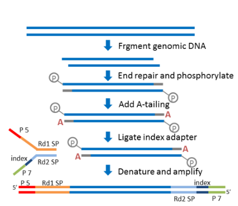

##### 图 1 二代文库构建流程

## 2.3 三代 SMRT（单分子测序技术 Single Molecule Real Time）测序流程

根据客户提供的 DNA 样本进行提取和样品检测、建库及测序，各个环节都严格把控。具体实验流程如下：  
1） 提取 DNA ：提取高质量的基因组 DNA ，并进行严格质控。基因组 DNA 打断成合适大小的大片段，然后进行损伤修复、接头连接、片段筛选等操作构建DNA文库；  
2） 文库构建：得到高质量纯化后的基因组 DNA 样品后，构建 PCR-free 的 SMRT bell 文库，通过 PacBio Sequel II 测序平台进行测序。  
3） 上机测序：文库经过片段筛选和定量后，将计算过的一定浓度和体积的文库模板和酶复合物转移到 PacBio Sequel II 测序仪的纳米孔里面，进行上机测序。  
4） 数据读取：PacBio 单分子测序原始下机数据序列记录保存在 subreads.bam 文件中,该文件中已经对测序接头和低质量序列进行了去除；数据读取采用 PacBio 官方软件 SMRTlink v8.0 对输出数据进行质控统计，最终得到有效数据。

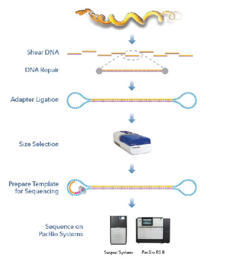

##### 图 2 三代文库构建流程

# 3 生物信息学分析

对测序得到的序列进行低质量数据过滤得到有效数据，基于过滤后数据，进行组装及后续分析，最终得到完整的基因组序列。生物信息分析流程见下图：

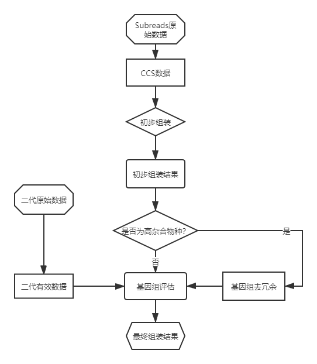

##### 图 3 基因组组装分析流程图

## 3.1 测序数据及其质量控制

### 3.1.1 测序数据格式

SMRT 测序得到的原始图像数据文件经碱基识别 **（Base Calling）**分析转化为原始数据（rawdata），结果以 FASTQ （简称为 fq）文件格式存储，其中包含测序序列（reads）的碱基信息以及其对应的测序质量信息。Raw Data 以 FASTQ 格式存储，每个 read 由四行描述，如下：

表 1 FASTQ 格式示例

| @ST-E00600:415:HFV5LALXX:1:1101:21486:1031 1:N:0:TGACAGGT |
| --- |
| GATCTGGTCCTCTCGGACCGCGATTCTTGCCTTCTGTGAACCTCGACAGATCGATCTTGAACCTCGACAGATCGATCTTGAACCTCGA |
| + |
| AAFFFAAFFFAAFFFAAFFFAAFFFAAFFFAAFFFAAFFFAAFFFAAFFFAAFFFAAFFFAAFFFAAFFFAAFFFAAFFFAAFFFAAF |

注：第一行以 “@” 开头，为 Illumina 测序标识符（Sequence Identifie）和描述文字（选择性部分），该行相当于 reads ID；第二行是碱基序列；第三行以 “+” 开头，后为 Illumina 测序标识符，一般为节省存储空间，省略 “+” 后测序标识符；第四行是对应碱基的测序质量，该行中每个字符对应的 ASCII 值减去 33，即为对应第二行碱基的测序质量值。

### 3.1.2 测序质量值

在测序过程中会存在一定的错误率，测序质量值可衡量碱基未正确检出的概率。如果测序错误率用 P 表示，碱基质量值用 **Q_score** 表示，则有如下关系：

$$Q_{-score} = -10 \times log_{10}P$$

每个碱基测序错误率是测序质量值**（Q_score）** 通过公式转化得到，而测序错误率是在碱基识别**（Base Calling）**过程中使用一种预测碱基判别发生错误概率模型计算得到的，对应关系如下表所示：

表 2 测序错误率与 Phred score 对应表

| Phred Quality Score | Probability of Incorrect Base Call | Base Call Accuracy |
| --- | --- | --- |
| Q10 | 1/10 | 90% |
| Q20 | 1/100 | 99% |
| Q30 | 1/1000 | 99.9% |
| Q40 | 1/10000 | 99.99% |

注：测序错误率分布具有两个特点：（1）测序错误率会随着测序序列（Sequenced Reads）长度的增加而升高，这是由于测序过程中化学试剂的消耗而导致错误；（2）前几个碱基的位置会发生较高的测序错误率，推测前几个碱基测序错误率较高的原因是由于随机引物碱基导致。

碱基质量值越高表明碱基识别正确率越高，碱基测序错误率越小。如：碱基质量值为 Q20，表示 100 个碱基中有1个会识别出错，即正确率 99% ；碱基质量值为Q30，表示 1,000 个碱基中有 1 个会识别出错，即正确率 99.9% ；Q40 表示 10,000 个碱基中有1 个会识别出错，即正确率 99.99% 。

### 3.1.3 数据过滤标准

由于原始测序数据（raw data）可能包含低质量序列、接头序列等，为了保证信息分析结果的可靠性，原始测序数据需要经过过滤，从而得到有效数据（clean data 或 pass reads），仍然以 FASTQ 格式存储（该序列文件可直接用于发表，公共数据库提交等，后续分析都基于此数据）。

**二代数据过滤：**

使用软件 FastQC （version：0.20.1）对原始 reads 进行过滤，丢弃低质量 reads，过滤标准如下：  
1） 去除 N 碱基含量超过 5% 的 reads；  
2） 去除低质量（质量值小于等于 5）碱基数目达到 50% 的 reads；  
3） 去除有 adapter 污染的 reads；  
4） 去除 PCR 扩增造成的重复序列。

**三代数据过滤：**

测序下机的 Polymerase reads经过如下处理后得到仅含插入片段的 Subreads，再使用 SMRTLink 8.0 软件对Subreads 进行处理生成 HiFi reads（参数： –min-passes=3 –min-rq=0.99）：  
1） 去除长度小于 50bp 的 Polymerase reads；  
2） 去除质量值低于 0.8 的 Polymerase reads；  
3） 去除接头自连的 Polymerase reads；  
4） 去除 Polymerase reads 中的接头序列。

### 3.1.4 测序数据量统计

#### 3.1.4.1 二代测序数据量统计

二代测序经过滤后，得到有效测序数据（clean data）统计如下。

表 3 二代测序数据量信息统计

| Type | Total_reads | Total_bases | GC_content | Q20 | Q30 |
| --- | --- | --- | --- | --- | --- |
| rawdata | 381,756,918 | 57,263,537,700 | 36.24% | 97.92% | 93.04% |
| cleandata | 380,360,398 | 57,054,059,700 | 36.24% | 97.92% | 93.04% |

注：Type 为数据类型；Total_reads 为测序 reads 数； Total_bases 为测序总碱基数；GC_Content 为 G/C 碱基数占总碱基数量的百分比；Q20、Q30 分别为 Phred 数值大于 20、30 的碱基占总体碱基的百分比。

#### 3.1.4.2 三代测序数据量统计

PacBio 单分子测序原始下机数据序列记录保存在 subreads.bam 文件中,该文件中已经对测序接头和低质量序列进行了去除，使用 PacBio 官方软件SMRTlink v8.0 对输出数据进行质控统计，最终得到有效数据。

Polymerase Reads 统计：

表 4 Polymerase Reads 统计

[output not shown]

注：sampleid：样本名称；polymerase reads number：Polymerase Reads 的数目；polymerase reads base(bp)：Polymerase Reads 总碱基数目；Average polymerase reads length(bp)：平均 Polymerase Reads 读长；polymerase reads length N50(bp)：将Polymerase Reads 按长度从长到短排列，依次累加 Polymerase Reads 的长度直到不小于总长度 50% 时对应的 Polymerase Reads 长度。

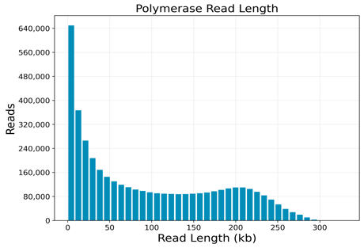

##### 图 4 Polymerase Reads长度统计分布图

注：横坐标为测序的 polymerase-reads 长度，纵坐标为不同长度对应的 polymerase-reads 条数。

## 3.2 K-mer 分析

K-mer 是指一段长度为 K bp 的序列。从一段连续序列中迭代地选取长度为 K 个碱基的序列，若序列的长度为 L，K-mer 长度为 K，那么可以得到 L-K+1 个 K-mer。我们对测序得到的 reads 取 K-mer，然后统计每个 K-mer 出现的频数。根据 Lander_waterman 算法，基因组大小(G)满足如下公式：

$$C_{base} = C_{k-mer} \times \frac{L}{L-K+1}$$

$$G =\frac{n_{k-mer}}{C_{k-mer}}=\frac{n_{base}}{C_{base}}$$

注：C<sub>base</sub> 和 C<sub>k-mer</sub> 为覆盖碱基的期望深度和 K-mer 期望覆盖深度，n<sub>base</sub> 和 n<sub>k-mer</sub> 为序列的碱基总数和 K-mer 总数。在数据量一定的情况下，K-mer 的深度频数是服从泊松分布的，因此 K-mer 深度频数分布的峰值为对应的深度，作为 K-mer 期望深度的估计值。

K-mer 分布图大致分为以下几种：（1）当只有一个主峰时，该个体为纯合体或单倍体；（2）在 x = a 处出现主峰，x = 2a 处有一次峰，说明一部分片段出现的期望值是大部分的 2 倍，这些片段为重复片段，次峰为重复峰；（3）在 x = a 处出现主峰，x = 0.5a 处有一个次峰，说明部分片段出现的期望值是大部分的 1/2，当序列有杂合时，包含杂合位点的 K-mer 因为分成了两部分，所以出现频率变为一半，次峰为杂合峰；（4）当出现两个主峰，且峰高相差不大，两峰横坐标又是 2 倍关系，说明该个体高杂合或高重复。

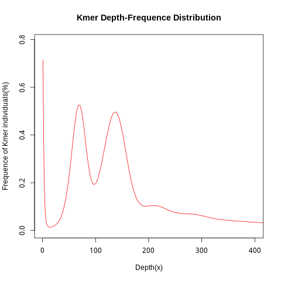

##### 图 5 Kmer-Depth 和 KmerSpecies - Individuals 分布图

注：横坐标为Kmer=17时的深度，纵坐标为不同深度的频率。

表 5 基因组大小估计

| Sample | K-mer | K-mer Number | Revised K-mer Num | K-mer Depth | Genome Size (M) | Data Size(bp) | X | Heterozygous Ratio(%) | Duplication Ratio(%) |
| --- | --- | --- | --- | --- | --- | --- | --- | --- | --- |
| B1 | 17 | 43,003,564,093 | 40,556,944,508 | 134 | 300 | 57,054,059,700 | 190 | 2.13 | 43.41 |

Sample 为样品名，Kmer 为 K-mer 的长度，Kmer Number 为 K-mer 的总数，Kmer Depth 为 K-mer 平均深度（即主峰深度），Genome Size（Mbp）为 K-mer 分析估计的基因组大小，Data Size(G) 为 clean_data 的数据量，X 为测序的深度，Heterozygous Ratio(%) 为杂合率, Duplication Ratio(%) 为重复率。

## 3.3 基因组组装与评估

首先使用软件hifiasm（https://github.com/chhylp123/hifiasm） 进行基因组组装。对于高杂合物种来说，需要使用软件Purge_haplotigs （version：1.0.4）对纠错后基因组进行去杂合，从而得到最终的组装结果（Draft Genome）。

基因组组装评价一般从以下三个重要方面来进行：连续性，一致性及完整性。

### 3.3.1 基因组连续性评估

一般用基因组的 contig N50 大小来评价基因组的连续性。contig N50越大代表基因组的连续性越好。

表 6 组装结果数据统计

| Item | Value_hap1 | Value_hap2 |
| --- | --- | --- |
| Total_length(bp) | 319,635,944 | 314,025,738 |
| Total_length_withoutN(bp) | 319,635,944 | 314,025,738 |
| Total_number | 330 | 178 |
| GC_content(%) | 35.42 | 35.32 |
| N50(bp) | 29,499,436 | 29,314,725 |
| N90(bp) | 10,557,614 | 10,383,262 |
| Average(bp) | 968,593.77 | 1,764,189.54 |
| Median(bp) | 35,829.50 | 55,351.00 |
| Min(bp) | 15,733 | 17,879 |
| Max(bp) | 46,446,282 | 45,755,433 |

注：Total_length 为组装长度；Total_length_withoutN 为组装结果中不含 gap 的长度；Total_number 为组装的序列条数；GC_content 为 GC 含量；N50 为数据的 N50，将所有的序列按照从长到短排序后依次累加，当相加的长度达到总长度的一半时，最后一个加上的序列长度即为 N50；N90 算法同 N50；Average 为平均长度；Median 为中位长度；Min 为最小长度；Max 为最大长度。

### 3.3.2 基因组一致性评估

通过统计二代比对率，覆盖度来评估组装基因组的一致性。二代数据比对率（map_rate）表示已比对到参考基因组上的二代 clean reads 占总的二代Clean Reads 的比例。二代数据覆盖度（Coverage）表示已比对到二代 Clean Reads 上的参考基因组片段长度占参考基因组总长度的比例。基因组一致性较好时，二代比对率和覆盖度一般大于 90%。

利用软件 bwa（version：0.7.17-r1188）将二代高通量测序（如 Illumina 测序平台）得到的质控后 reads（clean reads）比对（mapping）到参考基因组上。统计二代比对率和覆盖度如下：

表 7 二代数据比对统计

| Type | Number_hap1 | Number_hap2 |
| --- | --- | --- |
| map_rate | 99.15% | 99.12% |
| Average_depth | 169.07 | 170.72 |
| Coverage | 99.77% | 99.81% |

注：map_rate 为二代数据比对率；Average_depth 为平均覆盖深度；Coverage 为覆盖率。

### 3.3.3 基因组完整性评估

使用软件 BUSCO（version：4.1.4；参数：–evalue 1e-05）来评估基因组组装的完整性。在基因组完整性较好时，BUSCO 评估中 Complete BUSCOs（C）的占比一般大于90%。

| Item | Number_hap1 | Percent(%)_hap1 | Number_hap2 | Percent(%)_hap2 |
| --- | --- | --- | --- | --- |
| Complete BUSCOs (C) | 253 | 99.2 | 253 | 99.2 |
| Complete and single-copy BUSCOs (S) | 241 | 94.5 | 242 | 94.9 |
| Complete and duplicated BUSCOs (D) | 12 | 4.7 | 11 | 4.3 |
| Fragmented BUSCOs (F) | 1 | 0.4 | 1 | 0.4 |
| Missing BUSCOs (M) | 1 | 0.4 | 1 | 0.4 |
| Total BUSCO groups searched | 255 | 100.0 | 255 | 100.0 |

注：Complete BUSCOs 为完整的 BUSCO；Complete and single-copy BUSCOs 为完整且单拷贝的 BUSCO；Complete and duplicated BUSCOs 为完整但多拷贝的 BUSCO；Fragmented BUSCOs 为不完整的 BUSCO；Missing BUSCOs 为缺失的 BUSCO；Total BUSCO groups searched 为本次使用 BUSCO 库中收录的保守蛋白基因的总数目。

# 4 软件及数据库列表

表9 软件及数据库汇总表

| 软件/数据库 | 版本 | 分析 | 网址 |
| --- | --- | --- | --- |
| GCE | 1.0.2 | 基因组survey | https://github.com/fanagislab/GCE |
| genomescope | 1.0.0 | 基因组survey | https://github.com/schatzlab/genomescope |
| dipasm | latest | hifi组装 | https://github.com/shilpagarg/dipasm |
| Nextdenovo | 2.4.0 | hifi组装 | https://github.com/Nextomics/NextDenovo |
| hifiasm | 0.14.2 | hifi组装 | https://github.com/chhylp123/hifiasm |
| hicanu | latest | hifi组装 | https://canu.readthedocs.io/en/latest/ |
| minimap2 | 2.17-r941 | 长序列比对 | https://github.com/lh3/minimap2 |
| bwa | 0.7.17-r1188 | 短序列比对 | https://github.com/lh3/bwa |
| samtools | 1.9 | 比对结果处理 | https://github.com/samtools/samtools |
| pilon | 1.23 | 二代序列纠错 | https://github.com/broadinstitute/pilon |
| purge_haplotigs | Latest Version | 去除杂合重复 | https://github.com/skingan/purge_haplotigs_multiBAM |

# 5 常见问题说明

Q1：结果文件都是什么？

A：上传目录中有readme.txt说明，详细介绍了每个文件所代表的内容。

Q2：fa文件用什么软件打开？

A:建议在Linux系统下打开；如果在windows系统下，推荐使用Sublime文本查看器打开，但对于某些大型基因组仍然会出现卡顿现象。

# 6 联系我们

[figure not shown]

```
客 服 电 话：027-62435310
客 服 邮 箱：service@benagen.com
公 司 网 站：www.benagen.com
公 司 地 址：武汉市洪山区光谷生物城C2-4栋5楼
```

# 7 参考文献

[1] Deamer D, Akeson M, Branton D: Three decades of nanopore sequencing. Nat Biotechnol 2016, 34:518-52.  
[2] Magi A, Semeraro R, Mingrino A, Giusti B, D’Aurizio R: Nanopore sequencing data analysis: state of the art, applications and challenges. Brief Bioinform 2017.  
[3] Jain M, Olsen HE, Paten B, Akeson M: The Oxford Nanopore MinION: delivery of nanopore sequencing to the genomics community. Genome Biol 2016, 17:239.  
[4] Krishnakumar R, Sinha A, Bird SW, Jayamohan H, Edwards HS, Schoeniger JS, Patel KD, Branda SS, Bartsch MS: Systematic and stochastic influences on the performance of the MinION nanopore sequencer across a range of nucleotide bias. Sci Rep 2018, 8:3159.  
[5] Cock P J, Fields C J, Goto N, et al. The Sanger FASTQ file format for sequences with quality scores, and the Solexa/Illumina FASTQ variants. Nucleic Acids Research, 2010, 38(6):1767.  
[6] Ewing B, Green P. Base-Calling of Automated Sequencer Traces Using Phred. II. Error Probabilities. Genome Research, 1998, 8(3):186-94.  
[7] Liu B, Shi Y, Yuan J, et al. Estimation of genomic characteristics by analyzing k-mer frequency in de novo genome projects. Quantitative Biology, 2013, 35(s 1–3):62-67.Ruan, J. and Li, H. (2019) Fast and accurate long-read assembly with wtdbg2.  
[8] Walker B J, Abeel T, Shea T, et al. Pilon: An Integrated Tool for Comprehensive Microbial Variant Detection and Genome Assembly Improvement. PLOS ONE, 2014, 9.  
[9] Li H, Durbin R. Fast and accurate short read alignment with Burrows–Wheeler transform[M]. 2009.  
[10] Li H E A. The Sequence Alignment / Map (SAM) Format. Bioinformatics, 2009, 25(1 Pt 2):1653-4.  
[11] Haas B J, Delcher A L, Mount S M, et al. Improving the Arabidopsis genome annotation using maximal transcript alignment assemblies. Nucleic Acids Research, 2003, 31(19):5654-5666.  
[12] Stanke M, Diekhans M, Baertsch R, et al. Using native and syntenically mapped cDNA alignments to improve de novo gene finding. Bioinformatics, 2008, 24(5):637-644.  
[13] Simao F A, Waterhouse R M, Ioannidis P, et al. BUSCO: assessing genome assembly and annotation completeness with single-copy orthologs. Bioinformatics, 2015: btv351.  
[14] Katharina J. Hoff, Simone Lange, Alexandre Lomsadze, Mark Borodovsky and Mario Stanke, “BRAKER1: Unsupervised RNA-Seq-Based Genome Annotation with GeneMark-ET and AUGUSTUS”, Bioinformatics, 2015, Nov 11.  
[15] Ter-Hovhannisyan et al Gene prediction in novel fungal genomes using an ab initio algorithm with unsupervised training, Genome Research (2008) 18, pp 1979-1090.  
[16] Büttner, E., Gebauer, A. M., Hofrichter, M., Liers, C., & Kellner, H. (2019). Draft Genome Sequence of Xylaria longipes DSM 107183, a Saprotrophic Ascomycete Colonizing Hardwood. Microbiology resource announcements, 8(12), e00157-19. doi:10.1128/MRA.00157-19  
[17] G. Gremme, V. Brendel, M.E. Sparks, and S. Kurtz. Engineering a software tool for gene structure prediction in higher organisms. Information and Software Technology, 47(15):965-978, 2005.  
[18] Benjamin Buchfink, Chao Xie & Daniel H. Huson (2015). Fast and Sensitive Protein Alignment using DIAMOND. Nature Methods, 12, 59–60.  
[19] Ai, C., Kong, L. CGPS: A machine learning-based approach integrating multiple gene set analysis tools for better prioritization of biologically relevant pathways  
[20] Jones P, Binns D, Chang H Y, et al. InterProScan 5: genome-scale protein function classification. Bioinformatics, 2014, 30(9):1236-1240.  
[21] Simon C Potter, Aurélien Luciani, Sean R Eddy, Youngmi Park, Rodrigo Lopez, Robert D Finn, HMMER web server: 2018 update, Nucleic Acids Research, Volume 46, Issue W1, 2 July 2018, Pages W200–W204.  
[22] E. P. Nawrocki and S. R. Eddy, Infernal 1.1: 100-fold faster RNA homology searches, Bioinformatics 29:2933-2935 (2013).  
[23] Nawrocki E P, Burge S W, Bateman A, et al. Rfam 12.0: updates to the RNA families database. Nucleic acids research, 2014: gku1063.  
[24] Ashburner M, Ball C A, Blake J A, et al. Gene Ontology: tool for the unification of biology. Nature genetics, 2000, 25(1): 25-29.  
[25] Eddy, S. R. Profile hidden Markov models. Bioinformatics,1998,14(9), 755-763.  
[26] Robert D. Finn, Penelope Coggill, Ruth Y. Eberhardt, et al. The Pfam protein families database: towards a more sustainable future.Nucleic acids research, 201644 (D1): D279-D285.  
[27] Saier M H, Tran C V, Barabote R D. TCDB: the Transporter Classification Database for membrane transport protein analyses and information. Nucleic acids research, 2006, 34(suppl 1): D181-D186.  
[28] Winnenburg R, Baldwin T K, Urban M, et al. PHI-base: a new database for pathogen host interactions. Nucleic acids research, 2006, 34(suppl 1): D459-D464.  
[29] Cantarel B L, Coutinho P M, Rancurel C, et al. The Carbohydrate-Active EnZymes database (CAZy): an expert resource for glycogenomics. Nucleic acids research, 2009, 37(suppl 1): D233-D238.  
[30] Petersen T N, Brunak S, von Heijne G, et al. SignalP 4.0: discriminating signal peptides from transmembrane regions. Nature methods, 2011, 8(10): 785-786.  
[31] Krogh A, Larsson B È, Von Heijne G, et al. Predicting transmembrane protein topology with a hidden Markov model: application to complete genomes. Journal of molecular biology, 2001, 305(3): 567-580.  
[32] Li L, Stoeckert CJ, Roos DS: OrthoMCL: identification of ortholog groups for eukaryotic genomes. Genome research 2003, 13:2178-2189.  
[33] Yang Z. PAML 4: phylogenetic analysis by maximum likelihood. Molecular biology and evolution, 2007, 24(8): 1586-1591.  
[34] Wang Y, Tang H, DeBarry JD, Tan X, Li J, Wang X, Lee T-h, Jin H, Marler B, Guo H: MCScanX: a toolkit for detection and evolutionary analysis of gene synteny and collinearity. Nucleic acids research 2012, 40:e49-e49.